# Week 11: Data Analysis and Interpretation Part II

# Conducting the Tests in SPSS

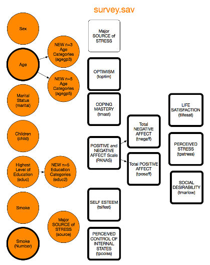

## Correlation

- Overview
- Focus
- Steps
- Alternative?
- SPSS

Also known as Pearson’s Product Moment or Pearson’s *r*

Assess relationship between *two continuous variables*

Variable 1: Total Perceived Stress (tpstress)

Variable 2: Total Perceived Control of Internal States (tpcoiss)

- Check for Outliers
- Inspect distribution of data points
- Determine direction of relationship
- Determine strength of relationship

The nonparametric* alternative is Spearman’s rho

*Inferential statistics that are used when the data do not meet the assumption of normality.

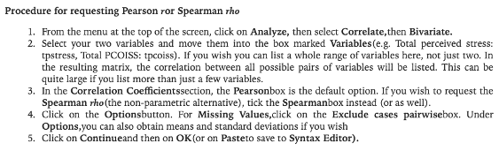

## Understanding the Output

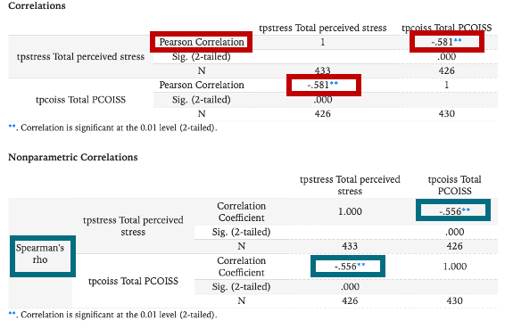

## Effect Sizes for r

- Small *r* = .10 to .29
- Medium *r* = .30 to .49
- Large *r* = .50 to 1.00

Cohen (1988, pp. 79-81)

## Writing it Up

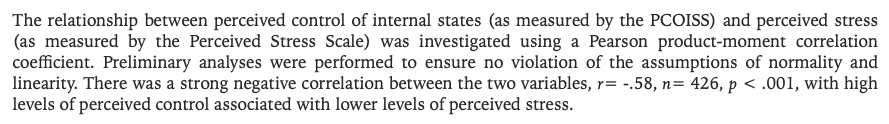

## Partial Correlation

- Overview
- Focus
- Steps
- SPSS

A measure of the relationship between the independent variable and the criterion variable, keeping the other independent variables constant.

TL;DR: It has a control.

Variable 1: Total Perceived Stress (tpstress)

Variable 2: Total Perceived Control of Internal States (tpcoiss)

Control: Total Social Desirability (tmarlow)

- Check assumptions (normality, linearity, homoscedasticity)
- Inspect distribution of data points
- Determine direction of relationship
- Determine strength of relationship

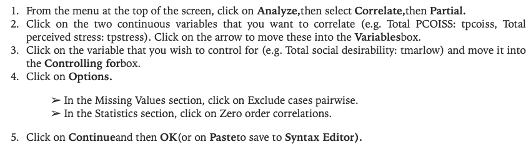

## Understanding the Output

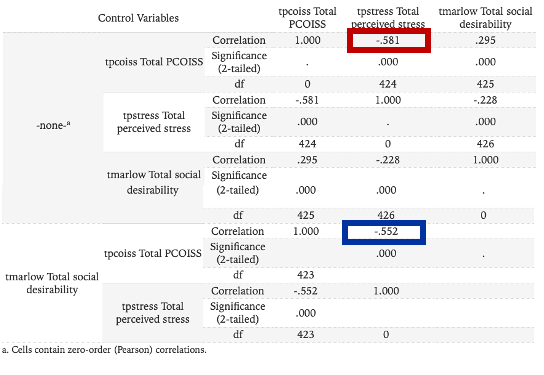

## Effect Sizes

- Small *r* = .10 to .29
- Medium *r* = .30 to .49
- Large *r* = .50 to 1.00

Cohen (1988, pp. 79-81)

## Writing it Up

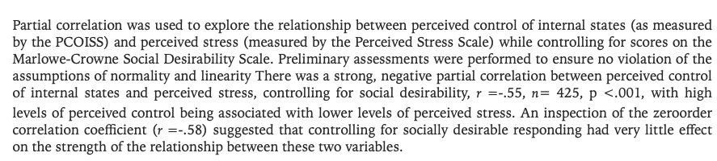

## Multiple Regression

- Overview
- Focus
- Assumptions
- SPSS

Includes several continuous and/or dichotomous IVs and one continuous DV

H1: How well do the two measures of control (mastery, PCOISS) predict perceived stress?

H2: Which is the best predictor of perceived stress: control of external events (mastery scale) or control of internal states (PCOISS)?

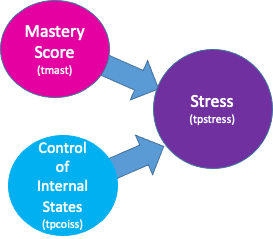

- DV should be at least interval (normally distributed)
  - IVs tend to be as well, but you can have dichotomous IVs. These are called dummy variables
- Must check for *Multicollinearity*
  - Occurs when there are high intercorrelations among some set of predictors
  - Two or more predictors contain much of the same information
- IVs are related to DVs in linear fashion
  - Straight line
  - Not curvilinear
- IVs should be correlated with the DVs, but not highly

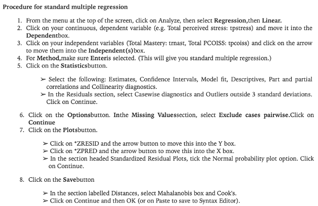

## Checking MR Assumptions

- Multicollinearity
- Normality
- Multivariate Outliers

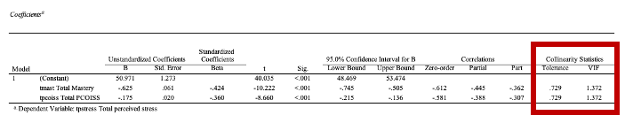

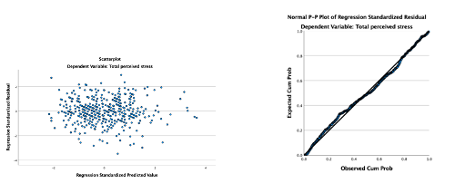

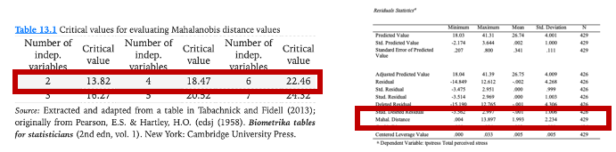

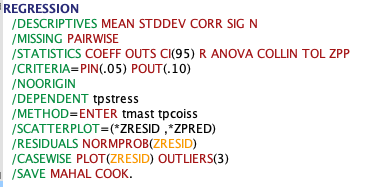

## Interpreting the Outpet

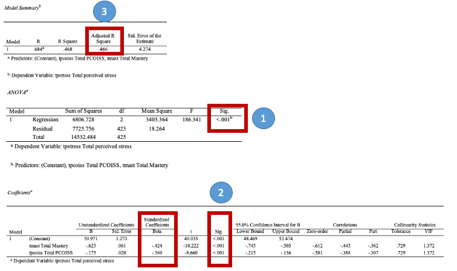

[figure not shown]

### Unstandardized Interpretation

For every 1 unit increase in mastery, perceived stress decreases by -.63 points

### Standardized Interpretation

For every 1 standard deviation increase in mastery, perceived stress decreases by -.42 standard deviation.

## Mediation & Moderation

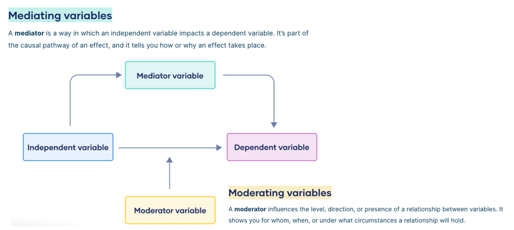

## Other Forms of Regression

- Logistic Regression
- Hierarchical Multiple Regression
- Stepwise Multiple Regression

A categorical outcome variable is something that is predicted to happen or not. Based largely in probability, as the outcome is dichotomous.

Variables are entered in steps, and the CHANGE in R2 is examined at each

The order is decided ahead of time

Are there things that need to be controlled? Enter these first!

The computer instead of the researcher decides the order and how many of the predictors are used.

Describes how much more each IV has contributed to the prediction from the predictors already used.

## Another Knowledge Check!

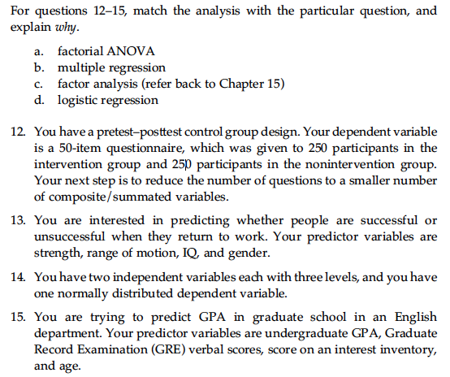

## Summary and Review

- Changing up next week to give more hands on analysis
- Example write ups and tables in Canvas
- There are too many types of regression
- Cannot say ‘predict’ unless design is experimental
- Theory is still driving choices

# Workshop: Connecting Surveys to CI SONA

## Broad Steps

- Finish surveys
- Double check them
- Complete [research subjects request form](https://uky.az1.qualtrics.com/jfe/form/SV_9Hy7vlzsnjtBypT)
- Get IRB approval and retain approval number
- Add survey to SONA

## Embedd ID

For Qualtrics:

- MUST add embed data to survey flow

[figure not shown]

## Setting up CI SONA

[figure not shown]

## Selecting the Type of Study

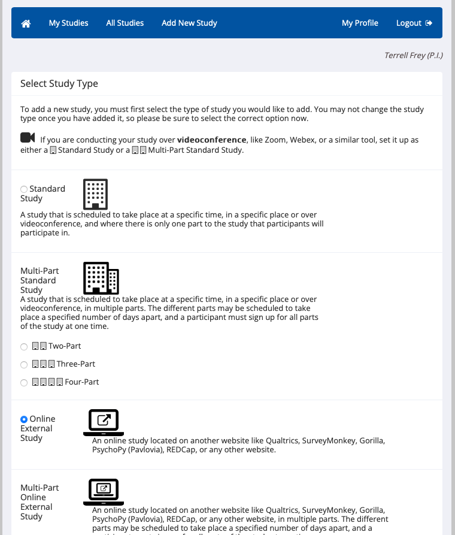

## Adding the tag

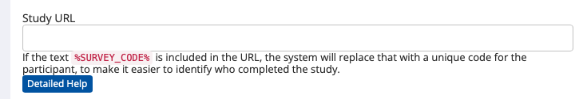

## Redirecting

After SONA generates your unique URL, you must add this back to Qualtrics so that participants are redirected.

## Scott Johnson

Add Scott Johnson (scott.johnson@uky.edu) as a collaborator.

He is the resident Qualtrics guru and keeper of the SONA.

[figure not shown]

tkfr222@uky.edu | [@TKFrey](https://twitter.com/TKFrey) | tkodyfrey.github.io